# EDA_sample_Rmd

티타임

2023-12-23

## 0. 패키지 불러오기기

```r
library(tidyverse)
library(GGally)
library(corrplot)
library(car)
library(reshape)
```

## 1. 데이터 불러오기

```r
breast_cancer_data <- read.csv(".//data//breast_cancer.csv")

# 변수명
colnames(breast_cancer_data)
```

```
##  [1] "id"                      "diagnosis"
##  [3] "radius_mean"             "texture_mean"
##  [5] "perimeter_mean"          "area_mean"
##  [7] "smoothness_mean"         "compactness_mean"
##  [9] "concavity_mean"          "concave.points_mean"
## [11] "symmetry_mean"           "fractal_dimension_mean"
## [13] "radius_se"               "texture_se"
## [15] "perimeter_se"            "area_se"
## [17] "smoothness_se"           "compactness_se"
## [19] "concavity_se"            "concave.points_se"
## [21] "symmetry_se"             "fractal_dimension_se"
## [23] "radius_worst"            "texture_worst"
## [25] "perimeter_worst"         "area_worst"
## [27] "smoothness_worst"        "compactness_worst"
## [29] "concavity_worst"         "concave.points_worst"
## [31] "symmetry_worst"          "fractal_dimension_worst"
## [33] "X"
```

```r
# 변수의 개수
ncol(breast_cancer_data)
```

```
## [1] 33
```

```r
# 전체 데이터의 개수
(total_count = nrow(breast_cancer_data))
```

```
## [1] 569
```

```r
# 양성 데이터의 개수
(Benign = nrow(breast_cancer_data %>% filter(diagnosis == "B")))
```

```
## [1] 357
```

```r
B_prob = Benign/total_count
names(Benign) = "Benign"

# 악성 데이터의 개수
(Malignant = nrow(breast_cancer_data %>% filter(diagnosis == "M")))
```

```
## [1] 212
```

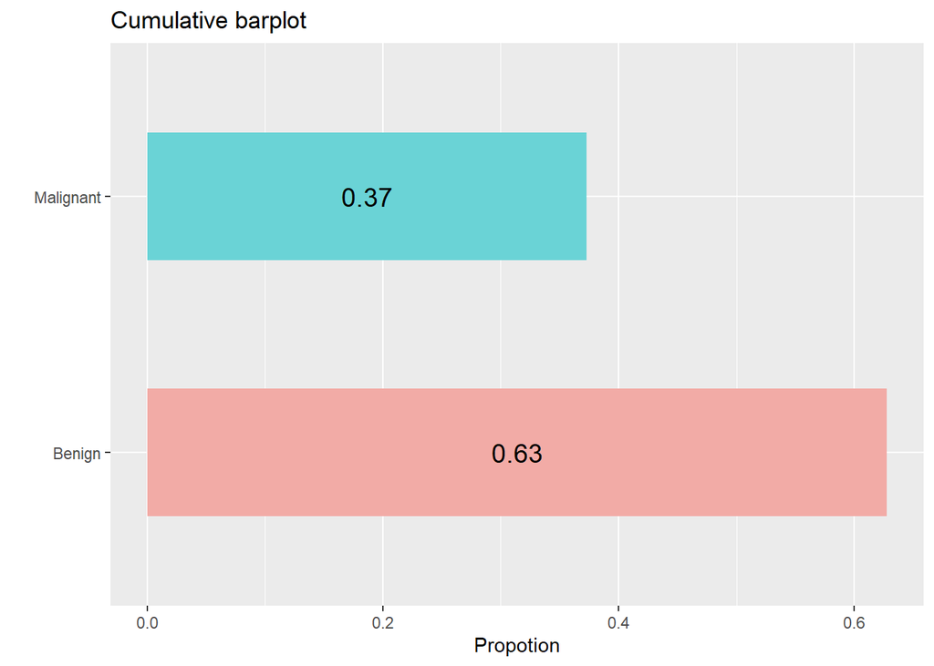

```r
M_prob = Malignant/total_count
names(Malignant) = "Malignant"

total_prob = data.frame(name = c("Benign", "Malignant"), value=c(B_prob, M_prob))

# 전체에서의 각 진단 비중.
ggplot(total_prob, aes(x=name, y=value, fill=name)) +
  geom_bar(stat="identity", width=0.5) +
  geom_text(aes(label = sprintf("%.2f", value)), position=position_stack(vjust=0.5), color="black", size=5) +
  labs(title="Cumulative barplot", y="Propotion", x="") +
  scale_fill_manual(values = c("Benign"= "#F2ABA6", "Malignant"="#6AD3D6")) +
  coord_flip() +
  theme(legend.position = "none")
```

양성 종양인 데이터(357EA)가 악성 종양인 데이터(212EA)보다 많다는 것을 확인할 수 있습니다.

- **Breast_Cancer 데이터**(UCL MACHINE LEARNING)
  - **변수**(총 33가지)
    - **id**(1)
    - **diagnosis**(2): Benign(양성=B), Malignant(악성=M)
    - **radius_mean, se, worst**(3, 13, 23): 중심에서 둘레까지의 거리의 평균, 표준오차, 최대값
    - **texture_mean, se, worst**(4, 14, 24): gray-scale 값의 표준편차의 평균, 표준오차, 최대값
    - **perimeter_mean, se, worst**(5, 15, 25): 핵 종양의 크기의 평균, 표준오차, 최대값
    - **area_mean, se, worst**(6, 16, 26): 핵 종양의 면적의 평균, 표준오차, 최대값
    - **smoothness_mean, se, worst**(7, 17, 27): 반지름 길이의 지역 변동의 평균, 표준오차, 최대값
    - **compactness_mean, se, worst**(8, 18, 28): $radius^2/area-1.0$의 평균, 표준오차, 최대값
    - **concavity_mean, se, worst**(9, 19, 29): 등고선의 오목한 부분의 심각도 평균, 표준오차, 최대값
    - **concave.points_mean, se, worst**(10, 20, 30): 등고선의 오목한 부분의 수의 평균, 표준오차, 최대값
    - **symmetry_mean, se, worst**(11, 21, 31): 대칭성의 평균, 표준오차, 최대값
    - **fractal_dimension_mean, se, worst**(12, 22, 32): $coastline approximation^{-1}$(해안선 근사치의 역수)의 평균, 표준오차, 최대값
    - **X**(33): 미 기재 변수
  - **변수**: 569개
    - **Benign**(양성)의 수: 357개
    - **Malignant**(악성)의 수: 212개

각 변수에 대해서 결측치가 존재하는지 확인하겠습니다.

```r
# 결측치 확인.
colSums(is.na(breast_cancer_data))
```

```
##                      id               diagnosis             radius_mean
##                       0                       0                       0
##            texture_mean          perimeter_mean               area_mean
##                       0                       0                       0
##         smoothness_mean        compactness_mean          concavity_mean
##                       0                       0                       0
##     concave.points_mean           symmetry_mean  fractal_dimension_mean
##                       0                       0                       0
##               radius_se              texture_se            perimeter_se
##                       0                       0                       0
##                 area_se           smoothness_se          compactness_se
##                       0                       0                       0
##            concavity_se       concave.points_se             symmetry_se
##                       0                       0                       0
##    fractal_dimension_se            radius_worst           texture_worst
##                       0                       0                       0
##         perimeter_worst              area_worst        smoothness_worst
##                       0                       0                       0
##       compactness_worst         concavity_worst    concave.points_worst
##                       0                       0                       0
##          symmetry_worst fractal_dimension_worst                       X
##                       0                       0                     569
```

X라는 변수열은 전체가 NA로 이루어져 있기 때문에 X 변수열을 제거하겠습니다.

```r
# X(33번 변수열) 제거거
breast_cancer_data = subset(breast_cancer_data, select=c(-33))

# 확인
str(breast_cancer_data)
```

```
## 'data.frame':    569 obs. of  32 variables:
##  $ id                     : int  842302 842517 84300903 84348301 84358402 843786 844359 84458202 844981 84501001 ...
##  $ diagnosis              : chr  "M" "M" "M" "M" ...
##  $ radius_mean            : num  18 20.6 19.7 11.4 20.3 ...
##  $ texture_mean           : num  10.4 17.8 21.2 20.4 14.3 ...
##  $ perimeter_mean         : num  122.8 132.9 130 77.6 135.1 ...
##  $ area_mean              : num  1001 1326 1203 386 1297 ...
##  $ smoothness_mean        : num  0.1184 0.0847 0.1096 0.1425 0.1003 ...
##  $ compactness_mean       : num  0.2776 0.0786 0.1599 0.2839 0.1328 ...
##  $ concavity_mean         : num  0.3001 0.0869 0.1974 0.2414 0.198 ...
##  $ concave.points_mean    : num  0.1471 0.0702 0.1279 0.1052 0.1043 ...
##  $ symmetry_mean          : num  0.242 0.181 0.207 0.26 0.181 ...
##  $ fractal_dimension_mean : num  0.0787 0.0567 0.06 0.0974 0.0588 ...
##  $ radius_se              : num  1.095 0.543 0.746 0.496 0.757 ...
##  $ texture_se             : num  0.905 0.734 0.787 1.156 0.781 ...
```

[output cut: 18 more lines]

X 변수열을 제거하고 `str()`로 확인하니, diagnosis 변수가 Char형 변수인 것을 확인했습니다. 이에 factor로 변환해줍니다.

```r
breast_cancer_data$diagnosis= as.factor(breast_cancer_data$diagnosis)

str(breast_cancer_data)
```

```
## 'data.frame':    569 obs. of  32 variables:
##  $ id                     : int  842302 842517 84300903 84348301 84358402 843786 844359 84458202 844981 84501001 ...
##  $ diagnosis              : Factor w/ 2 levels "B","M": 2 2 2 2 2 2 2 2 2 2 ...
##  $ radius_mean            : num  18 20.6 19.7 11.4 20.3 ...
##  $ texture_mean           : num  10.4 17.8 21.2 20.4 14.3 ...
##  $ perimeter_mean         : num  122.8 132.9 130 77.6 135.1 ...
##  $ area_mean              : num  1001 1326 1203 386 1297 ...
##  $ smoothness_mean        : num  0.1184 0.0847 0.1096 0.1425 0.1003 ...
##  $ compactness_mean       : num  0.2776 0.0786 0.1599 0.2839 0.1328 ...
##  $ concavity_mean         : num  0.3001 0.0869 0.1974 0.2414 0.198 ...
##  $ concave.points_mean    : num  0.1471 0.0702 0.1279 0.1052 0.1043 ...
##  $ symmetry_mean          : num  0.242 0.181 0.207 0.26 0.181 ...
##  $ fractal_dimension_mean : num  0.0787 0.0567 0.06 0.0974 0.0588 ...
##  $ radius_se              : num  1.095 0.543 0.746 0.496 0.757 ...
##  $ texture_se             : num  0.905 0.734 0.787 1.156 0.781 ...
```

[output cut: 18 more lines]

## 2. 분포에 대한 시각화.

다중공선성 문제를 해결하기 위한 1차적 변수 선택을 위해 변수간의 상관성을 다양하게 확인해보겠습니다.

- $\rho$의 기준(절대값)
  - $\rho \ge 0.8$: 높은 상관성
  - $0.4 \le \rho < 0.8$: 중간 정도의 상관성
  - $\rho < 0.4$: 약한 상관성성

### 2-1. 같은 변수에 대한 다른 지표 변수 간 상관성

#### Radius

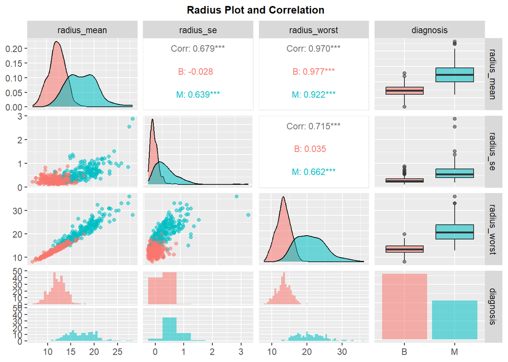

```r
 ggpairs(breast_cancer_data[,c(3, 13, 23, 2)],
        aes(color=diagnosis, alpha=0.3),
        lower=list(combo=wrap("facethist", binwidth=0.5)),
        upper=list(continuous = wrap("cor", size=3))) +
  labs(title="Radius Plot and Correlation") +
  theme(plot.title=element_text(face="bold", color="black", hjust=0.5, size=10))
```

radius에서 mean과 worst 간의 상관성이 강하게 나오고, mean과 se, se와 worst 간에는 약하지는 않지만 중간 정도의 상관성을 보인다.

#### Texture

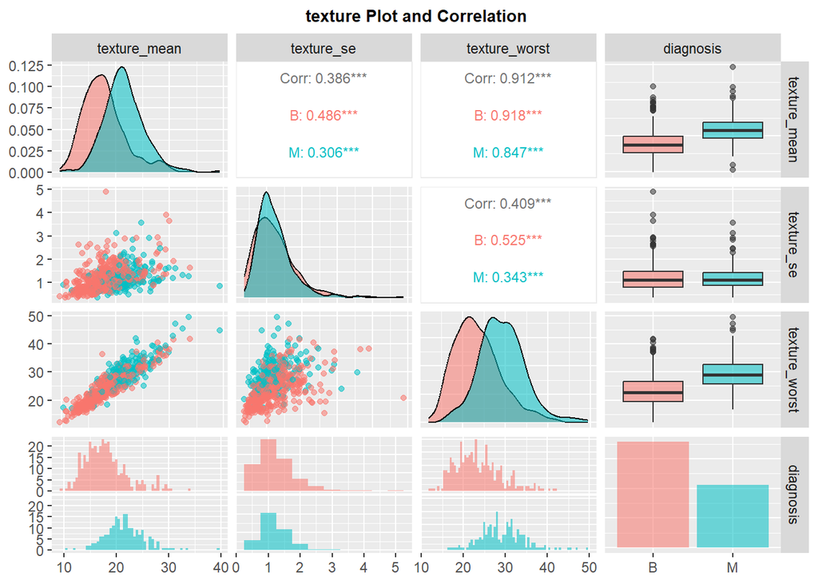

```r
ggpairs(breast_cancer_data[,c(4, 14, 24, 2)],
        aes(color=diagnosis, alpha=0.3),
        lower=list(combo=wrap("facethist", binwidth=0.5)),
        upper=list(continuous = wrap("cor", size=3))) +
  labs(title="texture Plot and Correlation") +
  theme(plot.title=element_text(face="bold", color="black", hjust=0.5, size=10))
```

#### Perimeter

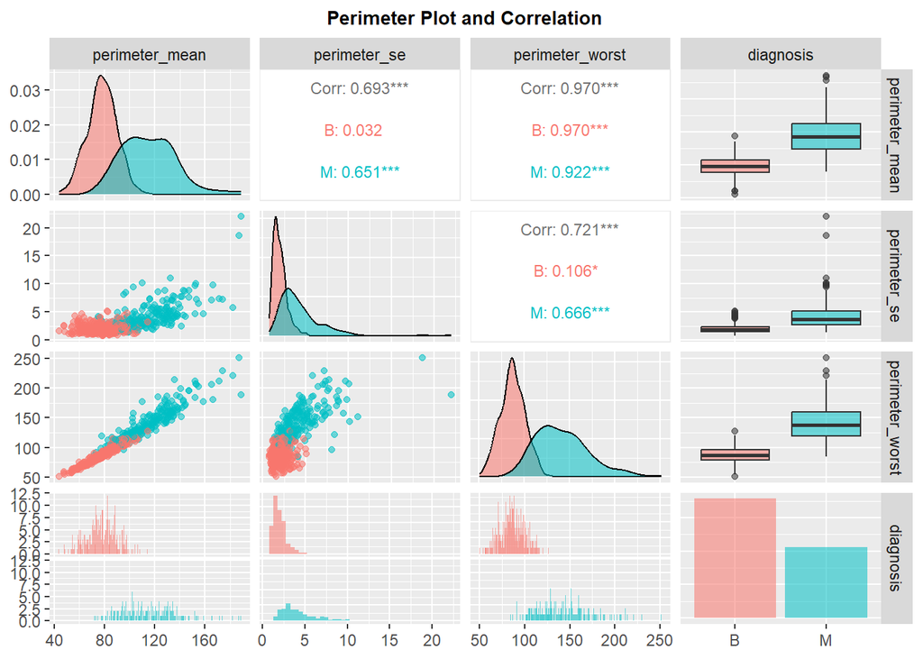

```r
ggpairs(breast_cancer_data[,c(5, 15, 25, 2)],
        aes(color=diagnosis, alpha=0.3),
        lower=list(combo=wrap("facethist", binwidth=0.5)),
        upper=list(continuous = wrap("cor", size=3))) +
  labs(title="Perimeter Plot and Correlation") +
  theme(plot.title=element_text(face="bold", color="black", hjust=0.5, size=10))
```

perimeter에서 mean과 worst 간의 상관성이 강하게 나오고, mean과 se, se와 worst 간에는 약하지는 않지만 어느 정도 중간 정도의 상관성을 보인다.

#### Area

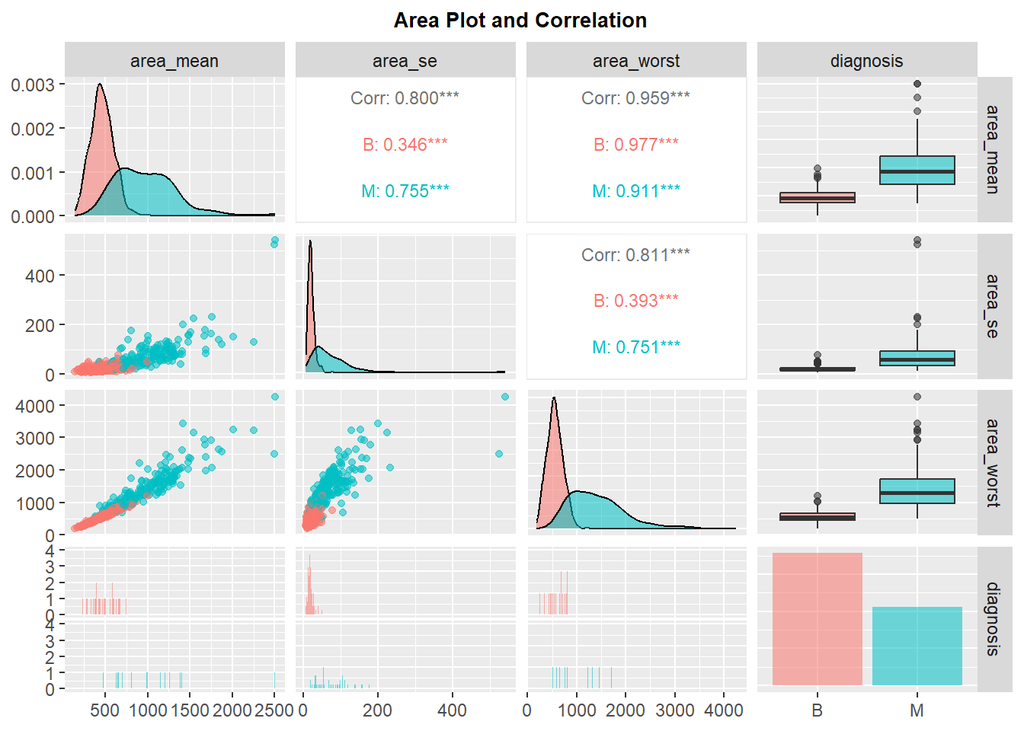

```r
ggpairs(breast_cancer_data[,c(6, 16, 26, 2)],
        aes(color=diagnosis, alpha=0.3),
        lower=list(combo=wrap("facethist", binwidth=0.5)),
        upper=list(continuous = wrap("cor", size=3))) +
  labs(title="Area Plot and Correlation") +
  theme(plot.title=element_text(face="bold", color="black", hjust=0.5, size=10))
```

area에서 mean, se, worst 간 상관성이 높게 나온다.

#### smoothness

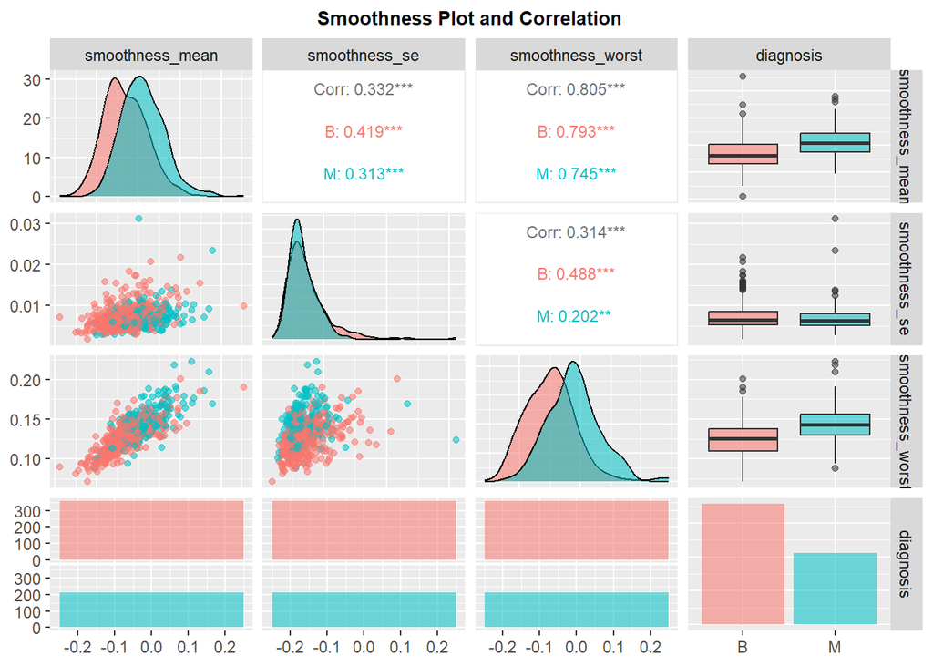

```r
ggpairs(breast_cancer_data[,c(7, 17, 27, 2)],
        aes(color=diagnosis, alpha=0.3),
        lower=list(combo=wrap("facethist", binwidth=0.5)),
        upper=list(continuous = wrap("cor", size=3))) +
  labs(title="Smoothness Plot and Correlation") +
  theme(plot.title=element_text(face="bold", color="black", hjust=0.5, size=10))
```

#### compactness

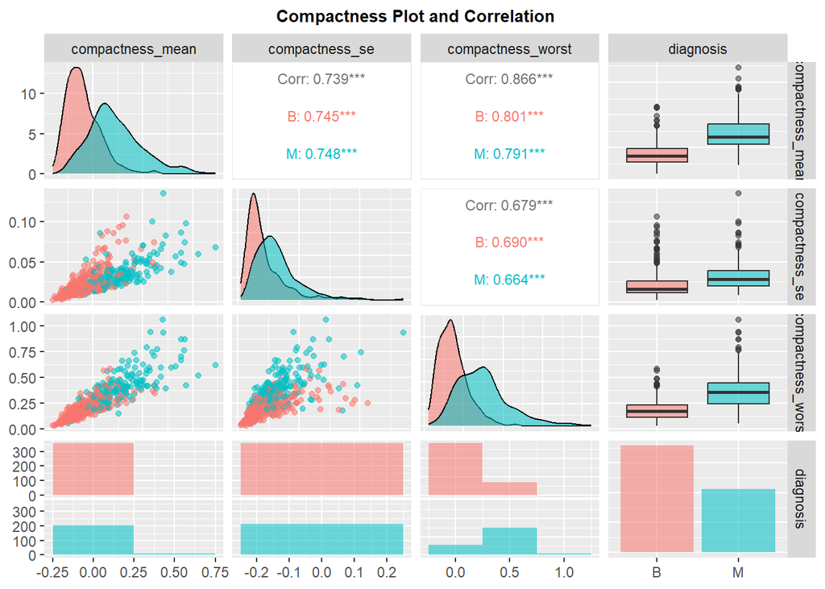

```r
ggpairs(breast_cancer_data[,c(8, 18, 28, 2)],
        aes(color=diagnosis, alpha=0.3),
        lower=list(combo=wrap("facethist", binwidth=0.5)),
        upper=list(continuous = wrap("cor", size=3))) +
  labs(title="Compactness Plot and Correlation") +
  theme(plot.title=element_text(face="bold", color="black", hjust=0.5, size=10))
```

compactness에서 mean과 worst 간 상관성은 높게 나오고, mean과 se, se와 worst 간에는 중간 정도의 상관성이 나온다.

#### concavity

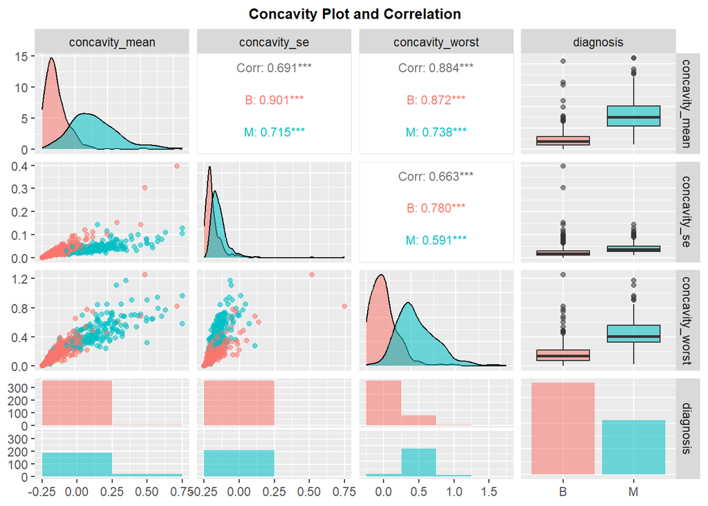

```r
ggpairs(breast_cancer_data[,c(9, 19, 29, 2)],
        aes(color=diagnosis, alpha=0.3),
        lower=list(combo=wrap("facethist", binwidth=0.5)),
        upper=list(continuous = wrap("cor", size=3))) +
  labs(title="Concavity Plot and Correlation") +
  theme(plot.title=element_text(face="bold", color="black", hjust=0.5, size=10))
```

concavity에서 mean과 worst 간 상관성은 높게 나오고, mean과 se, se와 worst 간에는 중간 정도의 상관성이 나온다.

#### concave.points

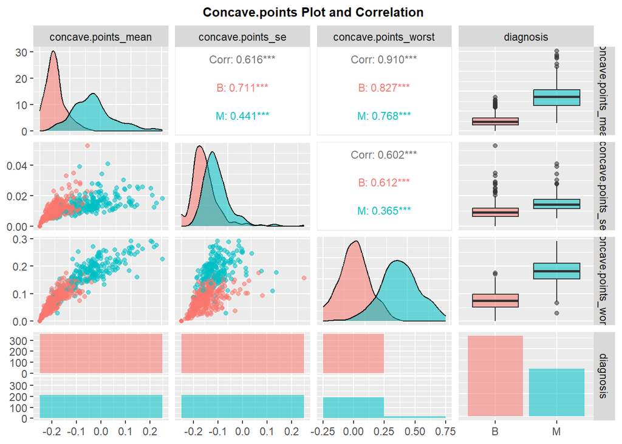

```r
ggpairs(breast_cancer_data[,c(10, 20, 30, 2)],
        aes(color=diagnosis, alpha=0.3),
        lower=list(combo=wrap("facethist", binwidth=0.5)),
        upper=list(continuous = wrap("cor", size=3))) +
  labs(title="Concave.points Plot and Correlation") +
  theme(plot.title=element_text(face="bold", color="black", hjust=0.5, size=10))
```

concave.points에서 mean과 worst 간 상관성은 높게 나오고, mean과 se, se와 worst 간에는 중간 정도의 상관성이 나온다.

#### symmetry

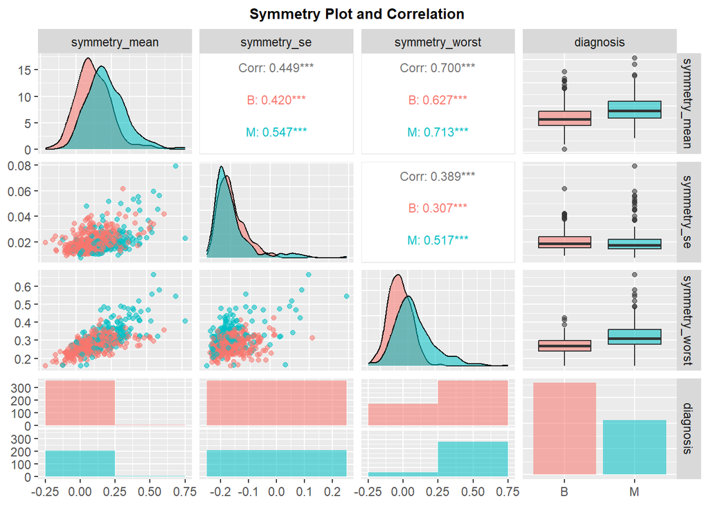

```r
ggpairs(breast_cancer_data[,c(11, 21, 31, 2)],
        aes(color=diagnosis, alpha=0.3),
        lower=list(combo=wrap("facethist", binwidth=0.5)),
        upper=list(continuous = wrap("cor", size=3))) +
  labs(title="Symmetry Plot and Correlation") +
  theme(plot.title=element_text(face="bold", color="black", hjust=0.5, size=10))
```

#### fractal.dimension

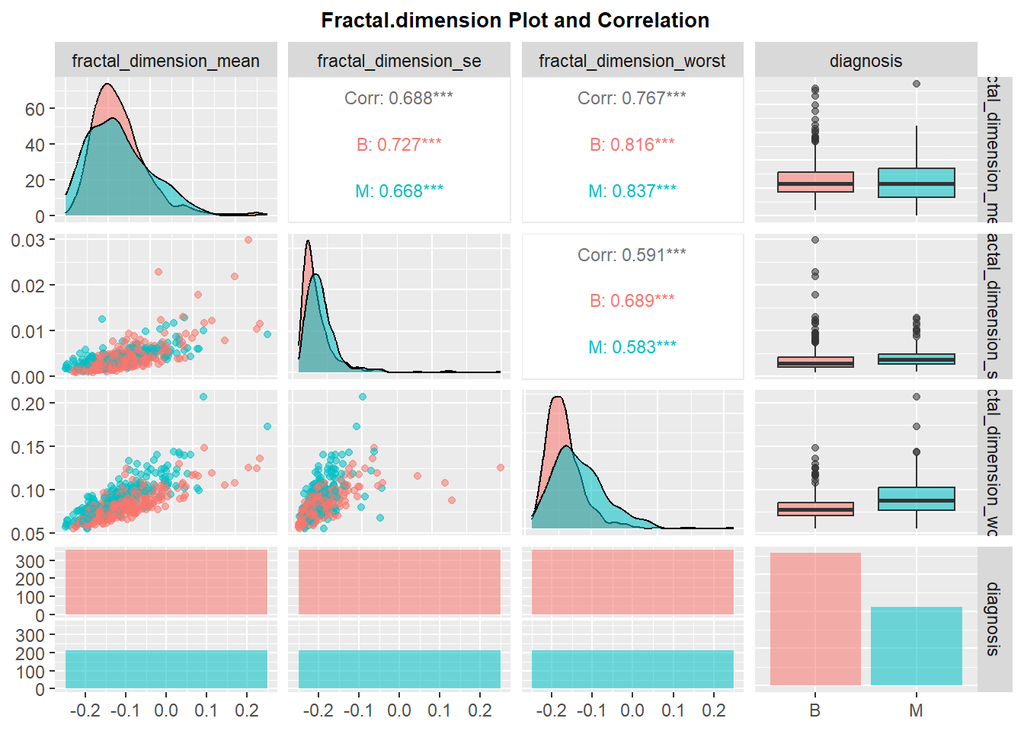

```r
ggpairs(breast_cancer_data[,c(12, 22, 32, 2)],
        aes(color=diagnosis, alpha=0.3),
        lower=list(combo=wrap("facethist", binwidth=0.5)),
        upper=list(continuous = wrap("cor", size=3))) +
  labs(title="Fractal.dimension Plot and Correlation") +
  theme(plot.title=element_text(face="bold", color="black", hjust=0.5, size=10))
```

fractal.dimension에서 mean, se, worst 간에는 중간 정도의 상관성을 보인다.

> mean과 worst 간의 상관계수는 대부분 0.8이상으로, 최소도 0.7이상으로 높게 나왔으나, mean과 se, se와 worst 간의 상관계수는 중간 혹은 그 이하가 나와 (mean se worst) 3가지 그룹 30개의 변수에서 (mean se) 2개의 그룹의 변수만을 선택해서 진행하도록 하겠습니다.

```r
breast_cancer_data = subset(breast_cancer_data, select=c(1:22)) # worst 그룹을 제거
```

### 2-2. 그룹 간의 상관성(worst 그룹 제외).

#### mean group

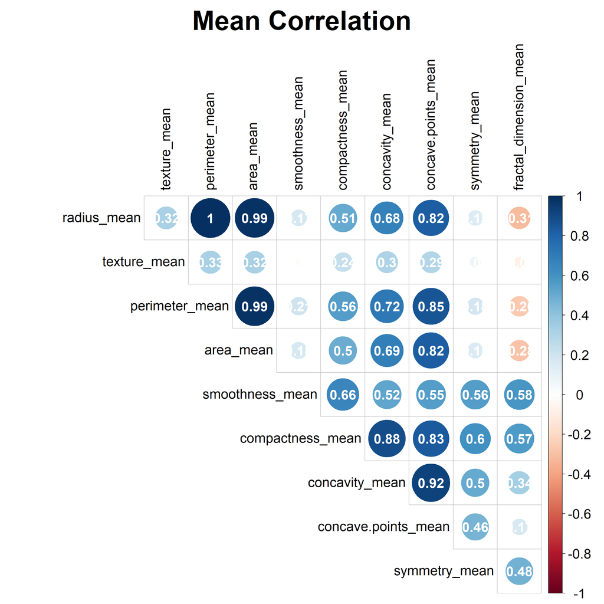

```r
corrplot(cor(breast_cancer_data[,c(3:12)]),
         type ="upper",
         order = "original",
         tl.col = "black",
         addCoef.col = "white",
         number.cex = 2,
         tl.cex = 2,
         title = "Mean Correlation",
         cex.main=4,
         cl.cex=2,
         diag=F,
         mar=c(0,0,5,0))
```

(radius perimeter area) 간의 상관계수가 0.8을 넘어 높은 상관성을 보이고, (compactness concavity concave.points) 간의 상관계수도 0.8을 넘어 높은 상관성을 보입니다.. 이 외에도 (area concave.points), (perimeter concave.points) (radius concave.points)가 0.8을 넘어 높은 상관성을 보입니다.

#### se group

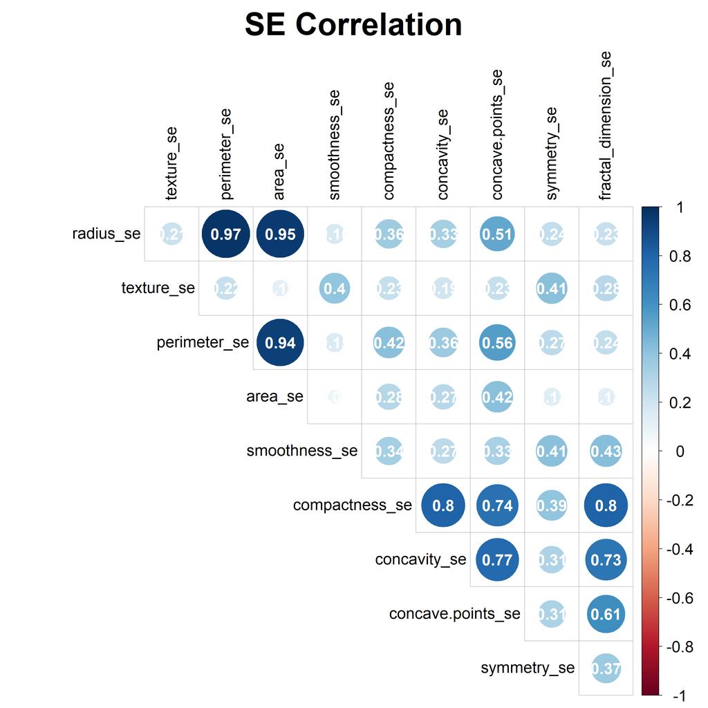

```r
corrplot(cor(breast_cancer_data[,c(13:22)]),
         type ="upper",
         order = "original",
         tl.col = "black",
         addCoef.col = "white",
         number.cex = 2,
         cl.cex= 2,
         tl.cex = 2,
         title = "SE Correlation",
         cex.main = 4,
         diag=F,
         mar=c(0,0,5,0))
```

(radius perimeter area) 간의 상관계수가 0.8을 넘어 높은 상관성을 보기ㅗ, (compactness concavity concave.points) 간의 상관계수도 0.7을 넘어 어느 정도 높은 상관성을 보입니다. 이 외에도 (compactness fractal.dimension)의 상관계수가 0.8을 넘어 높은 상관성을 보입니다.

> (radius perimeter area), (compactness concavity concave.points) 두 가지 그룹에 대해서 내부 변수 간의 상관성이 높게 나오는 것이 확인됩니다. 따라서 (radius perimeter area)에서 radius만을, (compactness concavity concave.points)에서 compactness만을 선택해서 mean, se 2개 그룹의 (radius texture smoothness compactness symmetry fractal.dimension) 총 12개의 변수를 최종 선택하겠습니다.

```r
data_selected = breast_cancer_data %>% select(!contains(c("perimeter", "area", "concavity", "concave.points")))
```

### 2-3. diagnosis에 따른 변수들의 분포

#### 2-3-1. mean

##### box plot

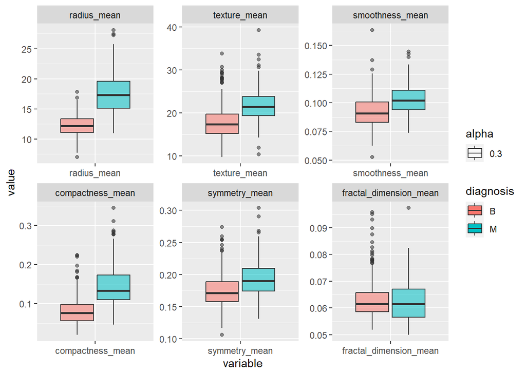

```r
breast_melt1 = melt(data_selected[,c(2:8)], id.vars = "diagnosis")
ggplot(breast_melt1, aes(x=variable, y=value)) +
  geom_boxplot(aes(alpha=0.3,fill=diagnosis)) +
  facet_wrap(~variable,scale="free")
```

##### density plot

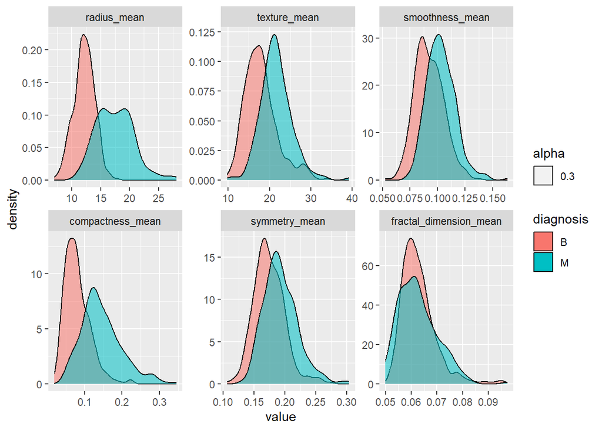

```r
ggplot(breast_melt1, aes(x=value, groups=variable)) +
  geom_density(aes(alpha=0.3,fill=diagnosis)) +
  facet_wrap(~variable,scale="free")
```

#### 2-3-2. se

##### boxplot

[figure not shown]

```r
breast_melt2 = melt(data_selected[,c(2,9:14)], id.vars = "diagnosis")
ggplot(breast_melt1, aes(x=variable, y=value)) +
  geom_boxplot(aes(alpha=0.3,fill=diagnosis)) +
  facet_wrap(~variable,scale="free")
```

##### density plot

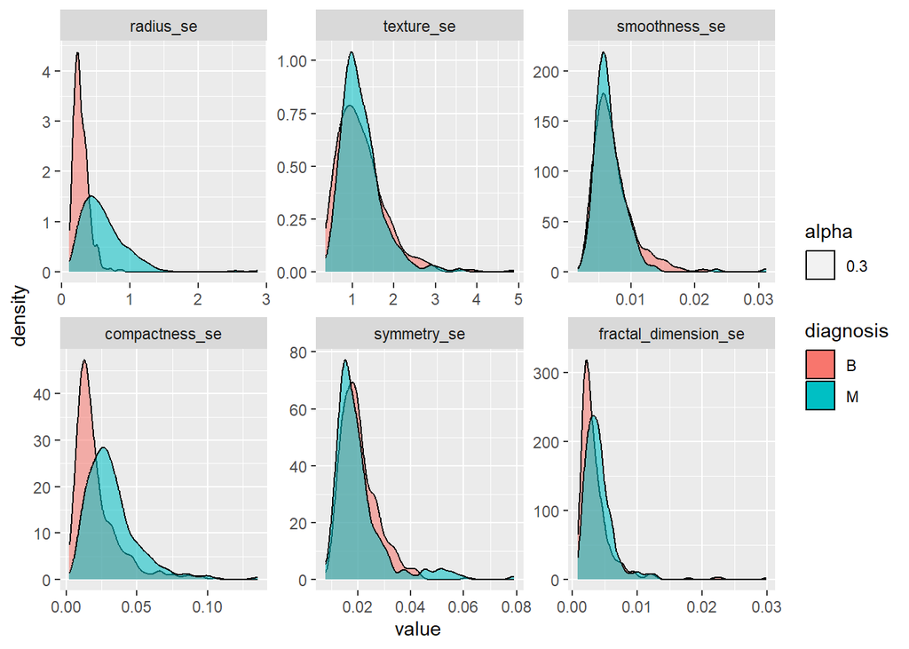

```r
ggplot(breast_melt2, aes(x=value, groups=variable)) +
  geom_density(aes(alpha=0.3,fill=diagnosis)) +
  facet_wrap(~variable,scale="free")
```